# Milestone Report

Tohaku

2023-04-02

## Introduction

This report is aimed to explore text data collected by SwiftKey. Firstly, the data files are summarized. Secondly, plots for the word frequencies are provided. Finally, a next-word prediction algorithm is briefly described.

## Set-up

```r
library(stringr)
library(dplyr)
library(ggplot2)
library(quanteda)
library(quanteda.textstats)
```

## Loading Data

```r
blogs_path <- "./final/en_US/en_US.blogs.txt"
con <- file(blogs_path, open = "rb");
blogs <- readLines(con, encoding = "UTF-8", skipNul = TRUE);
close(con)
```

```r
news_path <- "final/en_US/en_US.news.txt"
con <- file(news_path, open = "rb");
news <- readLines(con, encoding = "UTF-8", skipNul = TRUE);
close(con)
```

```r
twitter_path <- "./final/en_US/en_US.twitter.txt"
con <- file(twitter_path, open = "rb");
twitter <- readLines(con, encoding = "UTF-8", skipNul = TRUE);
close(con)
```

## Summary of the Data Sets

```r
file_name <- c("en_US.blogs.txt","en_US.news.txt","en_US.twitter.txt")
file_size <- file.size(c(blogs_path,news_path,twitter_path))/1024^2
line_count <- sapply(list(blogs,news,twitter), length)
word_count <- sapply(list(blogs,news,twitter),
                     function(x) sum(str_count(x,"\\w+")))
summary <- tibble(`File Name` = file_name,
                  `File Size (MB)` = file_size,
                  `Line Counts` = line_count,
                  `Word Counts` = word_count)
summary
```

```
## # A tibble: 3 × 4
##   `File Name`       `File Size (MB)` `Line Counts` `Word Counts`
##   <chr>                        <dbl>         <int>         <int>
## 1 en_US.blogs.txt               200.        899288      38309620
## 2 en_US.news.txt                196.       1010242      35624454
## 3 en_US.twitter.txt             159.       2360148      31003544
```

## Exploratory Analysis

Let’s sample 1% of the lines from each file.

```r
set.seed(1234)
blogs_sample <- sample(blogs, size = line_count[1] * 0.01)
news_sample <- sample(news, size = line_count[2] * 0.01)
twitter_sample <- sample(twitter, size = line_count[3] * 0.01)

rm(blogs)
rm(news)
rm(twitter)
```

Let’s summarize unigram, bigram, and trigram frequencies using the sampled datasets.

```r
token <- function(x) {
  x |>
    tokens(remove_numbers = TRUE,  remove_punct = TRUE) |>
    tokens_wordstem(language = quanteda_options("language_stemmer"))
}

unigram <- function(x) {
  x |>
    tokens_remove(stopwords("en")) |>
    dfm() |>
    textstat_frequency(n = 10)
}

ngram <- function(x,n) {
  x |>
    tokens_ngrams(n = n) |>
    dfm() |>
    textstat_frequency(n = 10)
}

freq_plot <- function(data, title) {
ggplot(data,aes(x = reorder(feature, frequency), y = frequency)) +
  geom_point() +
  coord_flip() +
  labs(x = NULL, y = "Frequency") +
  labs(title = title) +
  theme_minimal()
}
```

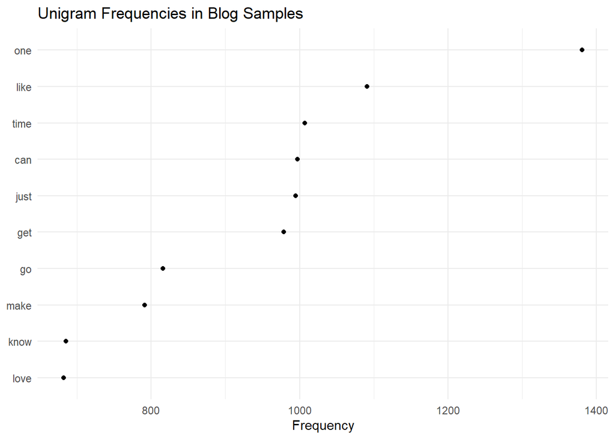

```r
blogs_token <- token(blogs_sample)
blogs_uni <- unigram(blogs_token)
freq_plot(blogs_uni, "Unigram Frequencies in Blog Samples")
```

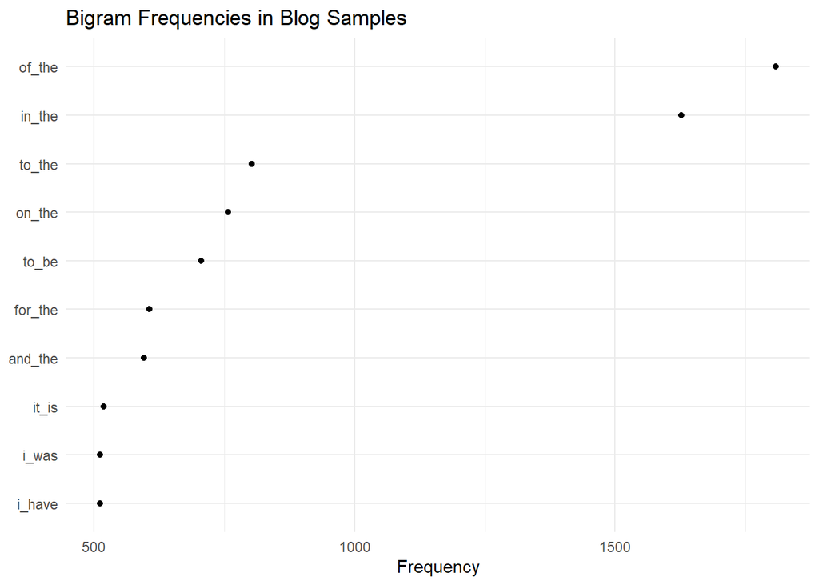

```r
blogs_bi <- ngram(blogs_token,2)
freq_plot(blogs_bi, "Bigram Frequencies in Blog Samples")
```

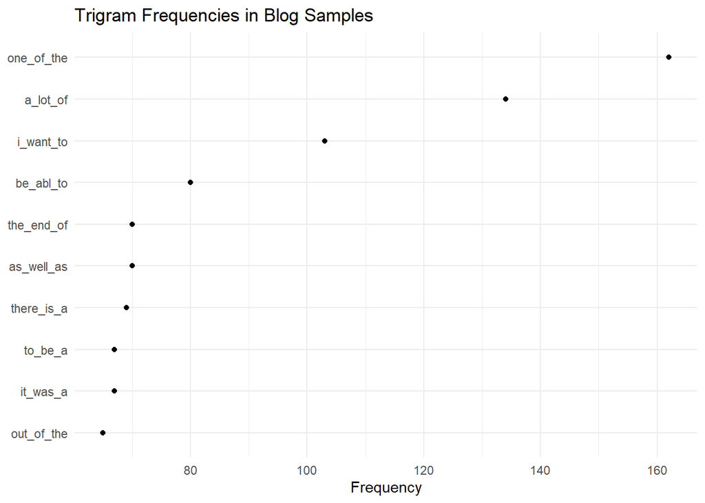

```r
blogs_tri <- ngram(blogs_token,3)
freq_plot(blogs_tri, "Trigram Frequencies in Blog Samples")
```

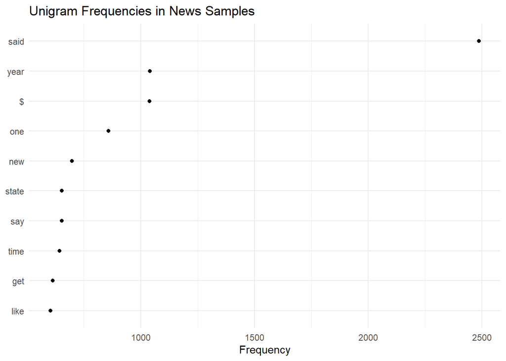

```r
news_token <- token(news_sample)
news_uni <- unigram(news_token)
freq_plot(news_uni, "Unigram Frequencies in News Samples")
```

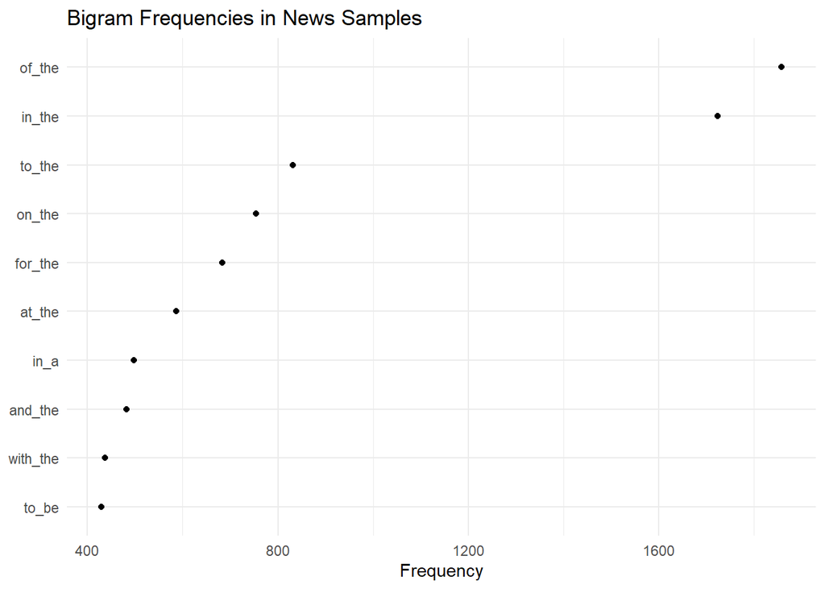

```r
news_bi <- ngram(news_token,2)
freq_plot(news_bi, "Bigram Frequencies in News Samples")
```

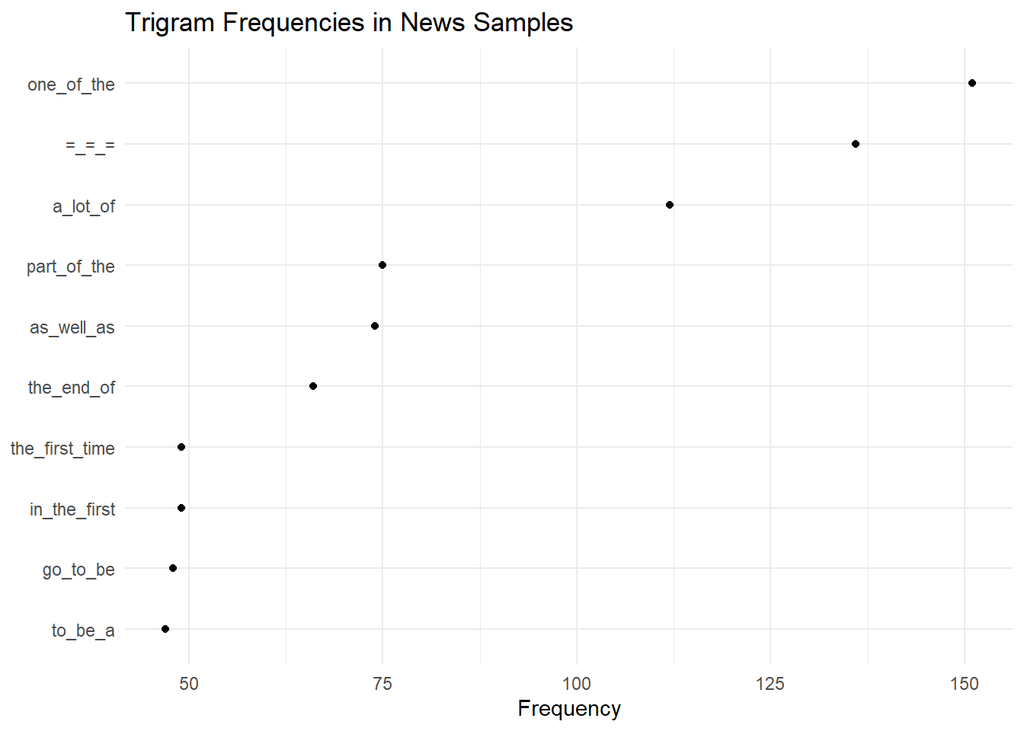

```r
news_tri <- ngram(news_token,3)
freq_plot(news_tri, "Trigram Frequencies in News Samples")
```

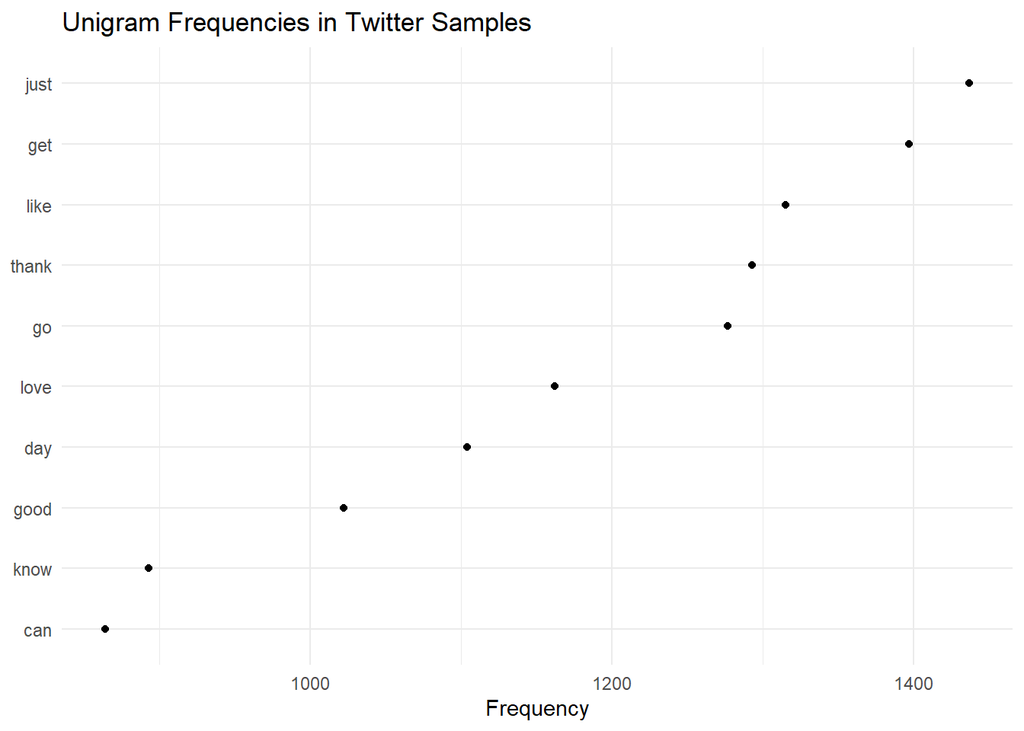

```r
twitter_token <- token(twitter_sample)
twitter_uni <- unigram(twitter_token)
freq_plot(twitter_uni, "Unigram Frequencies in Twitter Samples")
```

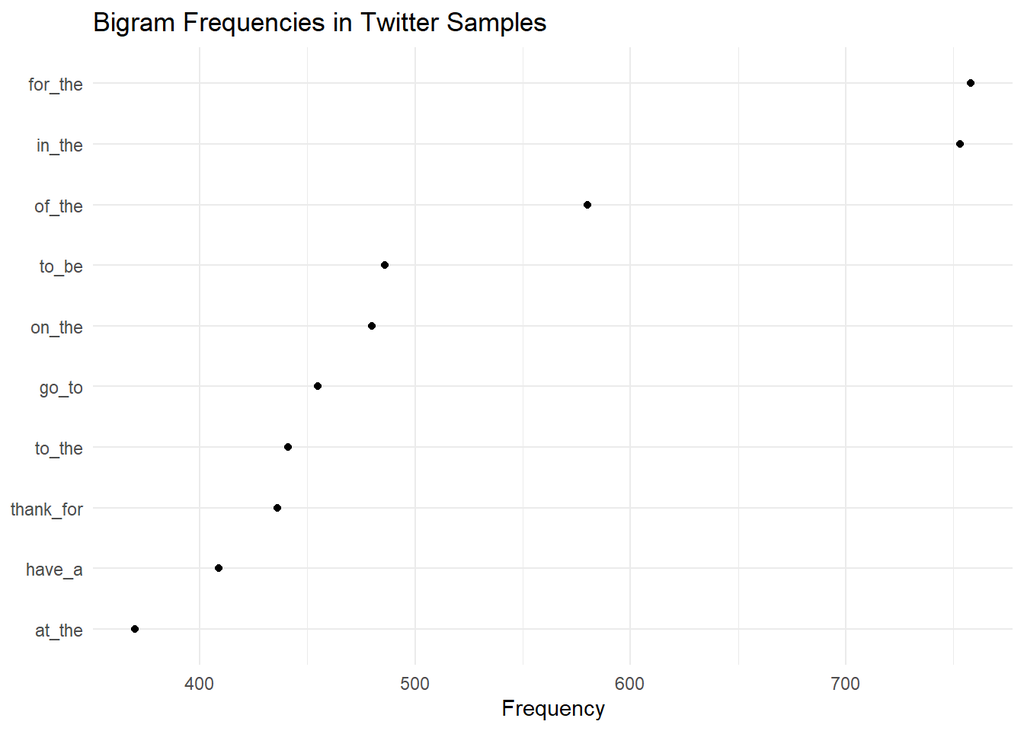

```r
twitter_bi <- ngram(twitter_token,2)
freq_plot(twitter_bi, "Bigram Frequencies in Twitter Samples")
```

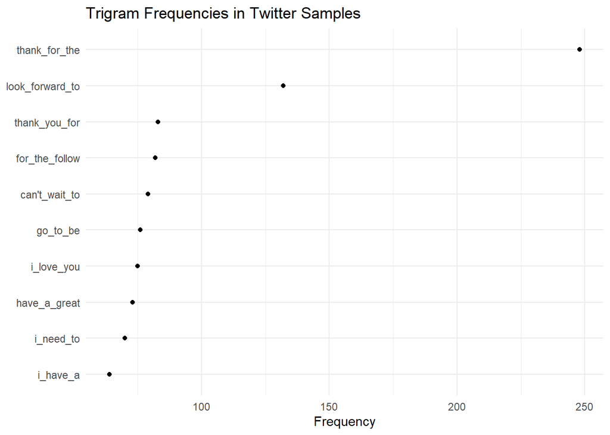

```r
twitter_tri <- ngram(twitter_token,3)
freq_plot(twitter_tri, "Trigram Frequencies in Twitter Samples")
```

## Findings

The Twitter samples include many subjective words like love and thank. The news samples include many objective words like said and year in contrast. The blog samples are in between.

## Plans for Prediction Algorithm and Shiny App

The Stupid Bake-off algorithm will be used for the next-word prediction. The model will be trained with unigram, bigram, and trigram samples from the blogs, news, and Twitter files. The [sbo package](https://vgherard.github.io/sbo/) will be used for the implementation. The trained model will be uploaded onto the server side of the Shiny app and used for prediction based on a phrase input on the UI side of the Shiny app.